# Hong Kong Shanghai and Shenzhen

Chen Jheng-Yi

2018/4/13

## Shanghai and Hong Kong

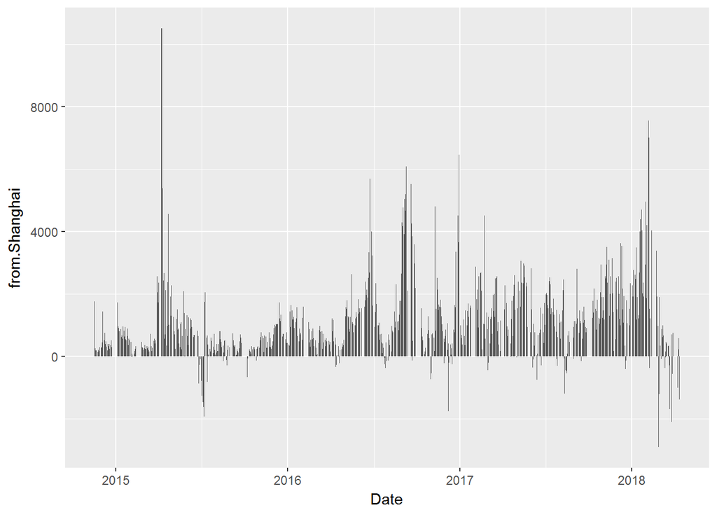

## Shanghai and Hong Kong

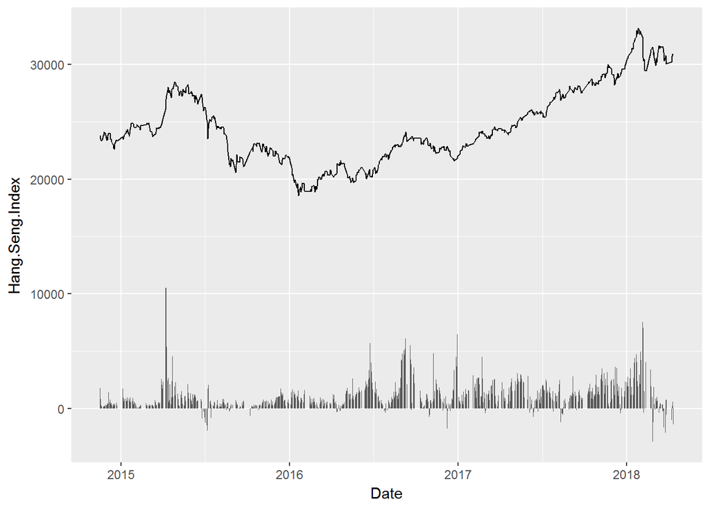

## Shanghai and Hong Kong

```r
dygraph(Shanghai_Shenzhen_to_Hong_Kong["/2016-12-05"]) %>%
  dySeries("from.Shanghai", axis = "y2") %>%
  dyRangeSelector(height = 10)
```

[interactive chart not shown]

## Shenzhen and Hong Kong

```r
dygraph(Shanghai_Shenzhen_to_Hong_Kong) %>%
  dySeries("from.Shenzhen", axis = "y2") %>%
  dyRangeSelector(height = 10)
```

[interactive chart not shown]

## Shanghai, Shenzhen and Hong Kong

[interactive chart not shown]


## Shenzhen and Hong Kong

```r
dygraph(Shanghai_Shenzhen_to_Hong_Kong) %>%
  dySeries("from.Shenzhen", axis = "y2") %>%
  dyRangeSelector(height = 10)
```

[interactive chart not shown]

## Shanghai, Shenzhen and Hong Kong

[interactive chart not shown]